# 02-Lab-PCA_guided

## 02-Lab - PCA

In this lab, you will load the digits dataset from sklearn.dataset and perform PCA on the dataset. The goal is to reduce the number of features and retain the information with minimal loss from the dataset.

As part of this, you would perform Standardise the data and perform PCA using sklearn.

```python
# Importing digits dataset
from sklearn import datasets
from sklearn.preprocessing import StandardScaler
from sklearn.decomposition import PCA as sklearnPCA
import pandas as pd
import numpy as np

digits = datasets.load_digits()

standardized_data = StandardScaler().fit_transform(digits['data'])
digits_df = pd.DataFrame(data=standardized_data)
digits_df.head()
# Write your code below to perform Principal Component Analysis (PCA) to reduce the dimensionality
```

```python
# carry out pca with 2 components and a random state of 12. Perform fit transform
# to get transfomred_vectors
# 1 line of code
transformed_vectors = # perform fit transform
labels = digits['target']
transformed_data_shape = transformed_vectors.shape
print("Shape of transformed data is {}".format(transformed_data_shape))
```

Shape of transformed data is (1797, 2)

```python
import matplotlib.pyplot as plt
from matplotlib.colors import ListedColormap
import plotly_express as px

colors = {0:'red', 1:'green',2:'blue', 3:'black', 4:'orange', 5:'pink', 6:'purple',7:'yellow', 8:'brown', 9:'olive'}

str_labels = # convert labels to strings, make sure it str_labels is a list
# data for pca_df should be a list where pca1 and pca2 are columns of transoformed vectors
# and the list st_labels
pca_df = pd.DataFrame(data= '####',
                      index=['pca1', 'pca2', 'labels']).T

# plotly figure
fig  = px.scatter(pca_df, x='pca1',
           y='pca2',
           hover_data=['labels'],
           color='labels',
           color_discrete_sequence=colors
           )
fig.update_traces( showlegend = True)
fig.show()
```

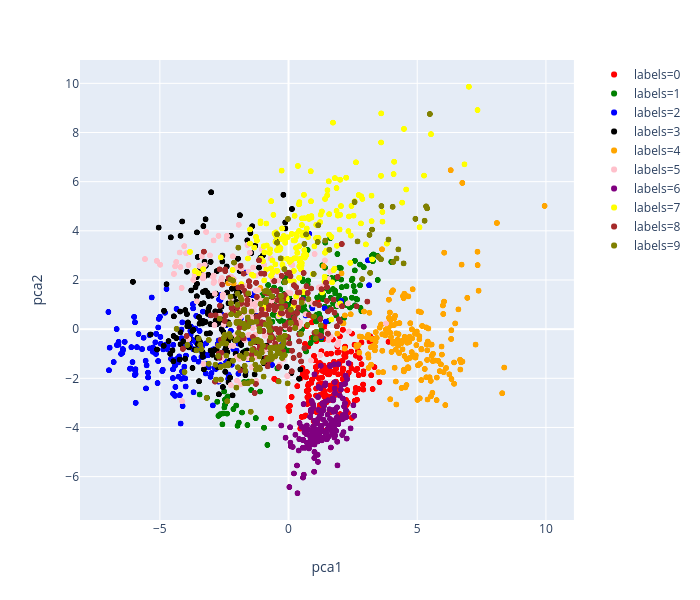

```python
np_labels = # convert labels not str_labels to numpy array
select_indices = # we need to select only labels where label = 0 or 9
selected_examples = # select only rows of data that have select indices from digits_df
selected_labels = np_labels[select_indices]
unique_selected_labels = np.unique(selected_labels)
print("selected_labels are {}".format(unique_selected_labels))
```

selected_labels are [0 9]

```python
pca = sklearnPCA(n_components=2, random_state=12 )
transformed_vectors = pca.fit_transform(selected_examples)
colors = {0:'red', 1:'olive'}

str_labels = [str(x) for x in selected_labels]
# similar to pca_df, we need to generate a list that consists of pca1
# pca2 and and str_labels which we will feed into the variable 'data'
pca_df_reduced = pd.DataFrame(data= '####',
                      index=['pca1', 'pca2', 'labels']).T


# plotly figure, refer to the figure for pca_df and enter the arguments
fig  = px.scatter('#####')
fig.update_traces( showlegend = True)
fig.show()
```

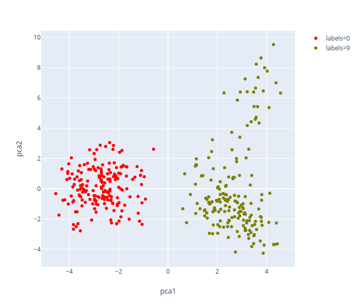

Let us look at which dimensions explain the variation the best. We can get the explained variances term from the model itself. It tells us how each pca dimension contributes to the variance.

## Part 2 : The cumulative explained variance plot

Let us now look at plotting how much variations is explained by the various pca dimensions. We shall plot the explained variance vs the number of components. The maximum number of components is the number of dimensions of the data. There are 64 features i.e 64 dimensions to the data. Each pixel is the equivalent to a dimension since each pixel can take a value between 0 and 255 and is its value is independent of its neighbors. As an aside, while the value of each pixel is independent of it's neighbor, there will be a strong correlation between a pixel's value and it's neighborhood values. If a pixel is surrounded by black pixels, there is a non-trivial probability that it will be black or vice versa.

Coming back to the topic. Let us plot the cumulative explained variance plot.

```python
pca = sklearnPCA(n_components=64, random_state=12 )
transformed_vectors = pca.fit_transform(selected_examples)

explained_variance_ratios = # get explained variance ratios from the pca model
cumulative_sum = # numpy has a tool that can do calcuate the cumulative sum. This should be an array
n_components = # you can use np.arange to get the number of components. Remember, you need 64 components

stacked_data = # you need to vertically stack the cumsum values and number of components and transpose them
cumsum_df = pd.DataFrame(data=stacked_data , columns=["variance", "n_components"])
px.line(cumsum_df, x="n_components", y="variance", title='Cumulative sum of variance' )
```

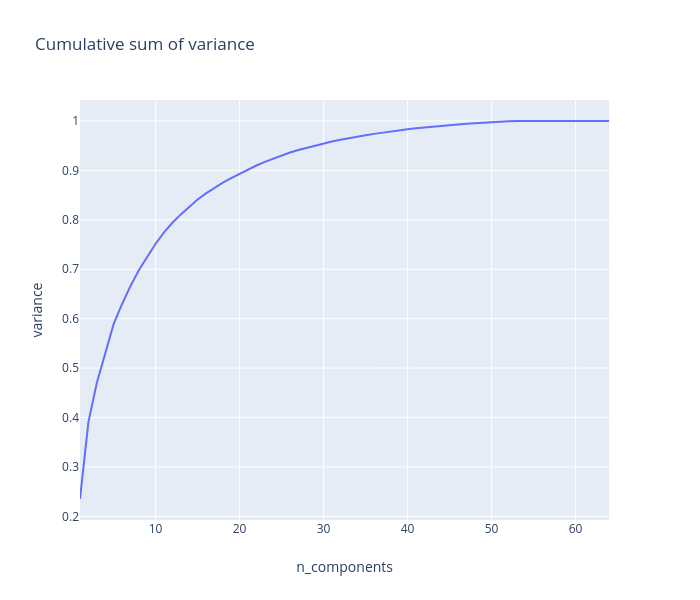

```python
# take the second value in the cumsum dataframe and multiply it by 100
print("The first two components explain {} of the variance".format("####"))
```

The first two components explain 39.05304261475776 of the variance

```python
# same as above but for the 10 th value
print("The first 10 components explain {} of the variance".format("####"))
```

The first 10 components explain 75.1555985864632 of the variance

```python
print("From the plot 90% of the variance is explained by a minimum of {} components".format(21))
```

From the plot 90% of the variance is explained by a minimum of 21 components